#### **To: Manager at General Mills**

#### **From: David Deans**

#### **Date: May 06, 2019**

#### **Insight into the effects of Promotion and Advertisement in our Industry**

# Introduction

In the cereal industry we have a wide array of products across numerous different flavors, including our competitors. Kelloggs, and to a smaller degree Post, have been taking advantage of similar promotions and advertising campaigns as us. In order to compete better in this industry, we need to understand where to have promotions, and which advertisements to use. Planning our budget as optimally as we can will give us a competitive edge against other companies. For the following insights our data will be measured on a Value system. The value generated will take the averages from our prices and units sold to give us a “score” of how well each particular decision plays out for us.

# Insight 1: Promotion does not always generate Value for General Mills

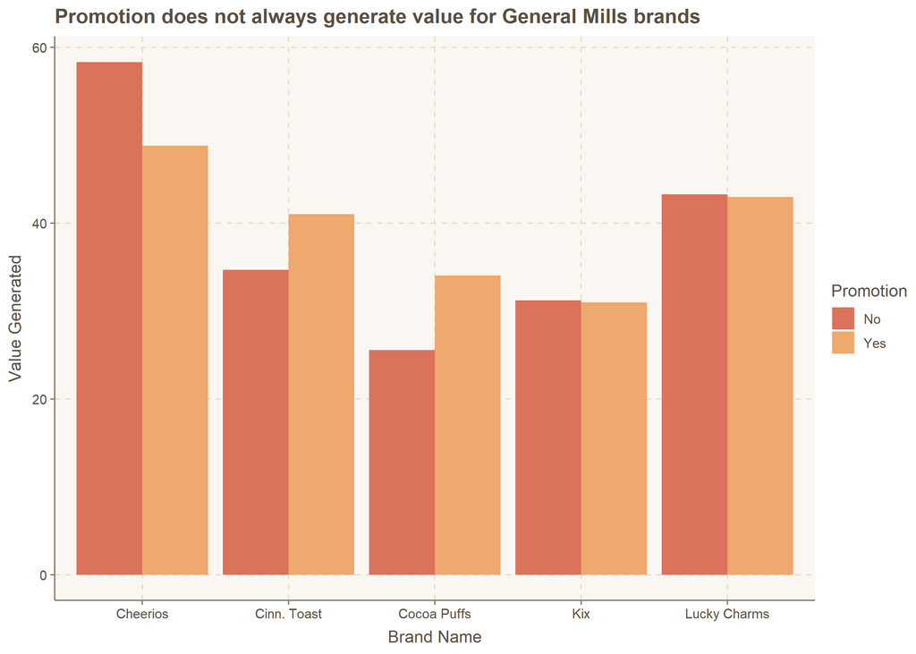

We have used promotion across all of the brands our company sells, but that is not always the best case. Graphed on the x axis is Brand Name and on the y axis is Value Generated. The brands are color-coded by whether a Promotion took place or not. While Kelloggs also does this, they typically gain more value as they sell more units than us. The visual above focuses on General Mills, and we can see that we should only be doing promotions on Cocoa Puffs and Cinnamon Toast Crunch. The value we get from running these promotions and selling additional units does not outweigh the lower price on our other brands.

# Insight 2: Atleast one form of advertisement is valuable for General Mills

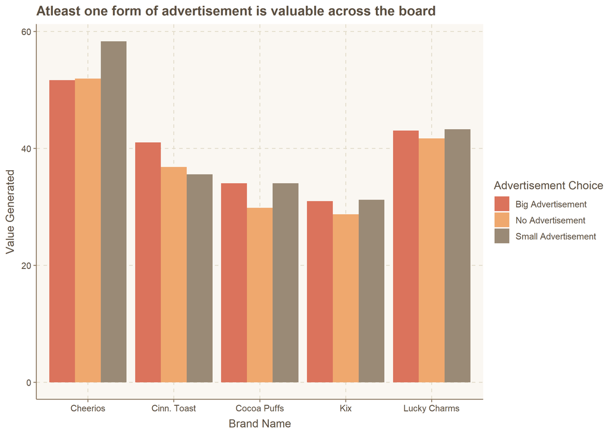

Here we are looking at the value generated for each brand from big advertisements, small advertisements, and no advertisements at all. Graphed on the x axis is Brand Name and on the y axis is Value Generated. The brands are color-coded by Advertisement Choice. Every brand benefits from at least one kind of advertisement. Cheerios only benefits from small advertisements, and Cinnamon Toast Crunch only benefits from large advertisements. The other three brands all benefit from advertisement near equally and can increase value as long as there is an advertisement of any size running for it.

# Conclusion

While promotion for our goods is a mixed bag on whether any promotion works or not, we can see clearly that General Mills always benefits from some form of advertisement per product. By paying attention to which brands benefit from Promotion (Cinnamon Toast Crunch and Cocoa Puffs) we make optimal decisions when promoting our brands. The same goes for advertisement. We should never purchase large advertisements for Cheerios and we should never purchase small advertisements for Cinnamon Toast Crunch, because they present less value than no advertisement. However, we should always advertise all of our products because there is an advertisement choice that is always more beneficial than no advertisement. By smartly promoting and advertising we can hopefully take more of Kelloggs marketshare.